# rapport-coffee rating

SijiaoLI

25/10/2020

```r
#install.packages("tidyverse")
library(tidyverse)
```

## I) Introduction

le grain de café joue un rôle très important dans la vie quotidienne. Il y a deux espèces de grains de café commercent économiquement dans le monde. Ce sont l’Arabica et le Robusta. Dans le monde, environ 60% de produits de café sont fabriqués par le grain de l’Arabica et 40% par le Robusta. D’ailleurs, les grains de café font une grande partie de commerce export pour les pays en développement. Les dégustateurs de café évaluent la qualité de grain de café en fonction du goût, en particulier de la douceur, de l’acidité et de l’arrière-goût. Les grains de café incarnent des saveurs révélatrices dans chaque région, donc les dégustateurs peuvent identifier l’origine du café.

Dans ce rapport, nous allons commencer une discussion sur la qualité des grains de café par 8 variables : la note générale (échelle de 0 à 100), les espèces des grains de café (arabica ou robusta), les pays d’origine des grains, les entreprises, les couleurs des grains, les régions des grains, Classe de douceur, Classe d’acidité. Enfin, après l’analyse ces données, nous pouvons sélectionner les grains de café de bonnes qualités lorsque nous ferons l’achat.

## II) Présentation des données

Ces données ont été collectées à partir des pages d’examen de Coffee Quality Institute en janvier 2018. J’ai pris ces données sur ce site: ‘https://raw.githubusercontent.com/rfordatascience/tidytuesday/master/data/2020/2020-07-07/coffee_ratings.csv’. Ils contiennent 1339 observations en colonnes et 43 variables en lignes. Dans mon rapport, je vais utiliser 8 variables et 1339 observations afin de procéder le jeu des données.

### 1) Obtention des données originales

```r
coffee_ratings <- readr::read_csv('https://raw.githubusercontent.com/rfordatascience/tidytuesday/master/data/2020/2020-07-07/coffee_ratings.csv')
coffee_ratings
```

```
## # A tibble: 1,339 x 43
##    total_cup_points species owner country_of_orig~ farm_name lot_number mill
##               <dbl> <chr>   <chr> <chr>            <chr>     <chr>      <chr>
##  1             90.6 Arabica meta~ Ethiopia         "metad p~ <NA>       meta~
##  2             89.9 Arabica meta~ Ethiopia         "metad p~ <NA>       meta~
##  3             89.8 Arabica grou~ Guatemala        "san mar~ <NA>       <NA>
##  4             89   Arabica yidn~ Ethiopia         "yidneka~ <NA>       wole~
##  5             88.8 Arabica meta~ Ethiopia         "metad p~ <NA>       meta~
##  6             88.8 Arabica ji-a~ Brazil            <NA>     <NA>       <NA>
##  7             88.8 Arabica hugo~ Peru              <NA>     <NA>       hvc
##  8             88.7 Arabica ethi~ Ethiopia         "aolme"   <NA>       c.p.~
##  9             88.4 Arabica ethi~ Ethiopia         "aolme"   <NA>       c.p.~
## 10             88.2 Arabica diam~ Ethiopia         "tulla c~ <NA>       tull~
## # ... with 1,329 more rows, and 36 more variables: ico_number <chr>,
## #   company <chr>, altitude <chr>, region <chr>, producer <chr>,
## #   number_of_bags <dbl>, bag_weight <chr>, in_country_partner <chr>,
## #   harvest_year <chr>, grading_date <chr>, owner_1 <chr>, variety <chr>,
## #   processing_method <chr>, aroma <dbl>, flavor <dbl>, aftertaste <dbl>,
## #   acidity <dbl>, body <dbl>, balance <dbl>, uniformity <dbl>,
## #   clean_cup <dbl>, sweetness <dbl>, cupper_points <dbl>, moisture <dbl>,
## #   category_one_defects <dbl>, quakers <dbl>, color <chr>,
## #   category_two_defects <dbl>, expiration <chr>, certification_body <chr>,
## #   certification_address <chr>, certification_contact <chr>,
## #   unit_of_measurement <chr>, altitude_low_meters <dbl>,
## #   altitude_high_meters <dbl>, altitude_mean_meters <dbl>
```

```r
#View(coffee_ratings)
```

### 2) Reconstruction des données-Sélecter les 8 variable

```r
new_table<-select(coffee_ratings,total_cup_points,species,country_of_origin,
                  company,region,color,acidity,sweetness)
new_table
```

```
## # A tibble: 1,339 x 8
##    total_cup_points species country_of_orig~ company region color acidity
##               <dbl> <chr>   <chr>            <chr>   <chr>  <chr>   <dbl>
##  1             90.6 Arabica Ethiopia         metad ~ guji-~ Green    8.75
##  2             89.9 Arabica Ethiopia         metad ~ guji-~ Green    8.58
##  3             89.8 Arabica Guatemala        <NA>    <NA>   <NA>     8.42
##  4             89   Arabica Ethiopia         yidnek~ oromia Green    8.42
##  5             88.8 Arabica Ethiopia         metad ~ guji-~ Green    8.5
##  6             88.8 Arabica Brazil           <NA>    <NA>   Blui~    8.5
##  7             88.8 Arabica Peru             richmo~ <NA>   Blui~    8.5
##  8             88.7 Arabica Ethiopia         <NA>    oromia <NA>     8.42
##  9             88.4 Arabica Ethiopia         <NA>    oromi~ <NA>     8.42
## 10             88.2 Arabica Ethiopia         diamon~ snnp/~ Green    8.5
## # ... with 1,329 more rows, and 1 more variable: sweetness <dbl>
```

### 3) Renommer les variables en français

Total rating/points (0 - 100 scale) =Note totale / points (échelle de 0 à 100), species =Espèce de grain de café (arabica ou robusta),country_of_origin=Pays d’origine du grain, company=Nom de l’entreprise, color=Couleur du grain,region=Région d’où provient le grain, sweetness=Classe de douceur, acidity=Classe d’acidité

```r
df<-new_table%>%
  rename("notes"="total_cup_points",
         "espèce"="species",
         "pays"="country_of_origin",
           "nom_entreprise"="company",
         "région"="region",
         "couleur"="color",
         "acidité"="acidity",
         "douceur"="sweetness")
df
```

```
## # A tibble: 1,339 x 8
##    notes espèce  pays   nom_entreprise      région      couleur  acidité douceur
##    <dbl> <chr>   <chr>  <chr>               <chr>       <chr>      <dbl>   <dbl>
##  1  90.6 Arabica Ethio~ metad agricultural~ guji-hambe~ Green       8.75   10
##  2  89.9 Arabica Ethio~ metad agricultural~ guji-hambe~ Green       8.58   10
##  3  89.8 Arabica Guate~ <NA>                <NA>        <NA>        8.42   10
##  4  89   Arabica Ethio~ yidnekachew debess~ oromia      Green       8.42   10
##  5  88.8 Arabica Ethio~ metad agricultural~ guji-hambe~ Green       8.5    10
##  6  88.8 Arabica Brazil <NA>                <NA>        Bluish-~    8.5    10
##  7  88.8 Arabica Peru   richmond investmen~ <NA>        Bluish-~    8.5    10
##  8  88.7 Arabica Ethio~ <NA>                oromia      <NA>        8.42    9.33
##  9  88.4 Arabica Ethio~ <NA>                oromiya     <NA>        8.42    9.33
## 10  88.2 Arabica Ethio~ diamond enterprise~ snnp/kaffa~ Green       8.5    10
## # ... with 1,329 more rows
```

### 4) Affiche la base de données

```r
#view(df)
```

### 5) Descriptif des données

```r
summary(df)
```

```
##      notes          espèce              pays           nom_entreprise
##  Min.   : 0.00   Length:1339        Length:1339        Length:1339
##  1st Qu.:81.08   Class :character   Class :character   Class :character
##  Median :82.50   Mode  :character   Mode  :character   Mode  :character
##  Mean   :82.09
##  3rd Qu.:83.67
##  Max.   :90.58
##     région            couleur             acidité         douceur
##  Length:1339        Length:1339        Min.   :0.000   Min.   : 0.000
##  Class :character   Class :character   1st Qu.:7.330   1st Qu.:10.000
##  Mode  :character   Mode  :character   Median :7.580   Median :10.000
##                                        Mean   :7.536   Mean   : 9.857
##                                        3rd Qu.:7.750   3rd Qu.:10.000
##                                        Max.   :8.750   Max.   :10.000
```

## III) Jeu des données et Graphiques

> Question 1 : Quel couleur de grain de café a la note le plus haute?

```r
note_haute_couleur<-df%>%
  select(notes,couleur)%>%
  group_by(couleur)%>%
  summarise(max_note=max(notes, na.rm = TRUE))

note_couleur<-df%>%
  select(notes,couleur)%>%
  group_by(couleur)%>%
  summarise(moyenne_note=mean(notes, na.rm = TRUE))%>%
left_join(note_haute_couleur, by = "couleur")
note_couleur
```

```
## # A tibble: 5 x 3
##   couleur      moyenne_note max_note
##   <chr>               <dbl>    <dbl>
## 1 Blue-Green           82.6     86.3
## 2 Bluish-Green         82.6     88.8
## 3 Green                81.9     90.6
## 4 None                 80.4     87.2
## 5 <NA>                 82.8     89.8
```

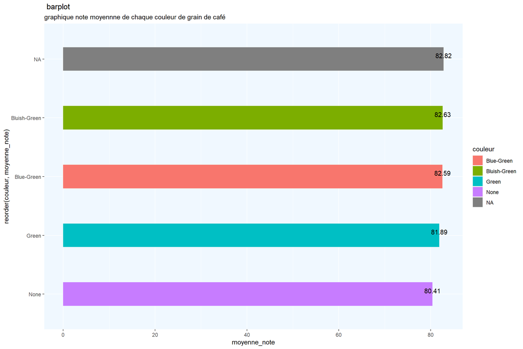

```r
plot0<-df%>%
  select(notes,couleur)%>%
  group_by(couleur)%>%
  summarise(moyenne_note=mean(notes, na.rm = TRUE))%>%
  ggplot(aes(x=moyenne_note,y=reorder(couleur,moyenne_note)))+
  geom_col(aes(fill = couleur),position = "dodge", width=0.4)+
  geom_text(aes(label=round(moyenne_note,2)),vjust=-0.2)+
  theme(panel.background = element_rect(fill = "aliceblue"))+
  labs(subtitle = "graphique note moyennne de chaque couleur de grain de café",title = " barplot")
plot(plot0)
```

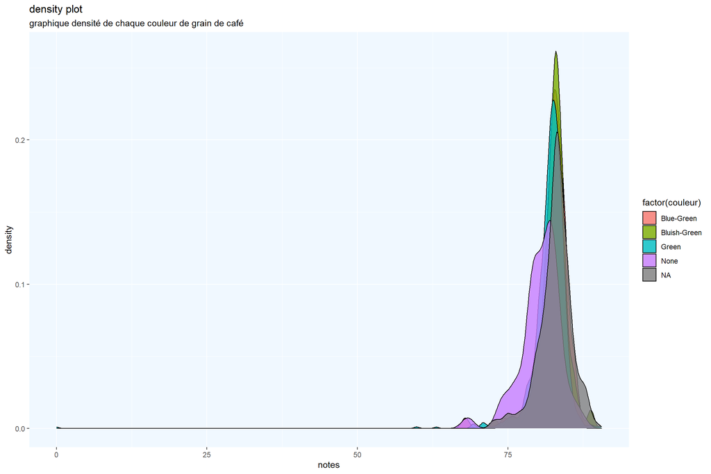

```r
plot1<-df%>%select(notes,couleur)%>%
  group_by(couleur)%>%
  ggplot(aes(x = notes))+
  geom_density(aes(fill=factor(couleur)), alpha=0.8)+
  theme(panel.background = element_rect(fill = "aliceblue"))+
  labs(subtitle = "graphique densité de chaque couleur de grain de café",title = "density plot")
plot(plot1)
```

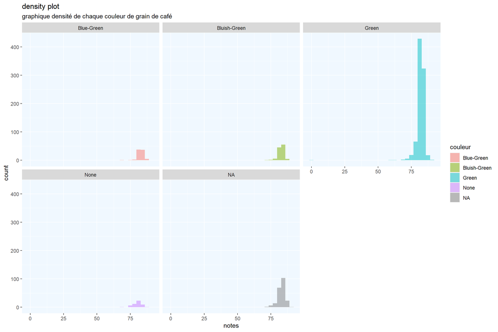

```r
plot2<-df%>%select(notes,couleur)%>%
  group_by(couleur)%>%
  ggplot(aes(x = notes))+
  geom_histogram(aes(fill = couleur), alpha = 0.5, position = "identity")+
  theme(panel.background = element_rect(fill = "aliceblue"))+
  labs(subtitle = "graphique densité de chaque couleur de grain de café",title = "density plot")+
  facet_wrap(~couleur)
plot(plot2)
```

> Question 2 :Quel espèce de grain (l’Arabica et le Robusta) a la moyenne de note plus haute ?

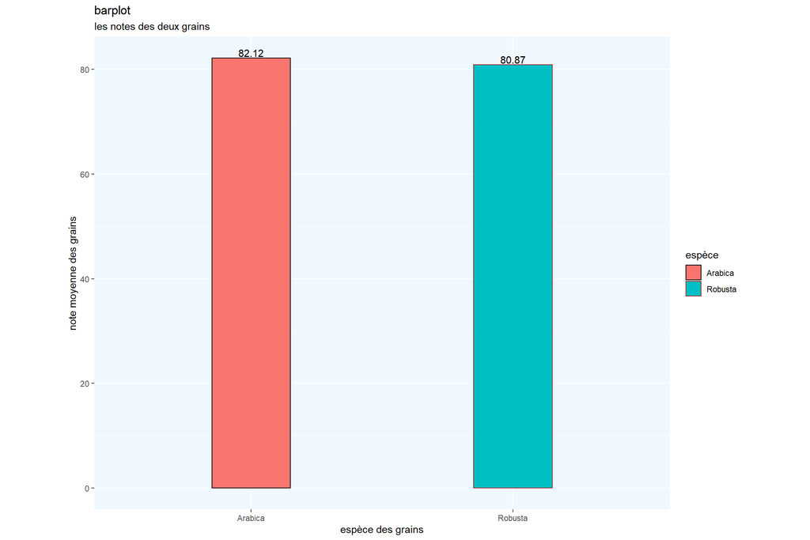

```r
df%>%filter(espèce %in% c("Arabica","Robusta"))%>%
  select(espèce,notes)%>%
  group_by(espèce)%>%
  summarise(notemoyenne=mean(notes,na.rm = TRUE))%>%
  ggplot(aes(y=notemoyenne,x=espèce))+
  geom_col(aes(color = espèce, fill = espèce),position = "dodge", width=0.3)+
  scale_color_manual(values = c("black", "brown"))+
  geom_text(aes(label=round(notemoyenne,2)),vjust=-0.2)+
  coord_fixed(ratio = 1/50)+
  theme(panel.background = element_rect(fill = "aliceblue"))+
  scale_size_area(max_size = 25)+
  labs(x="espèce des grains",y="note moyenne des grains",subtitle="les notes des deux grains",title = "barplot")->p1
 p1
```

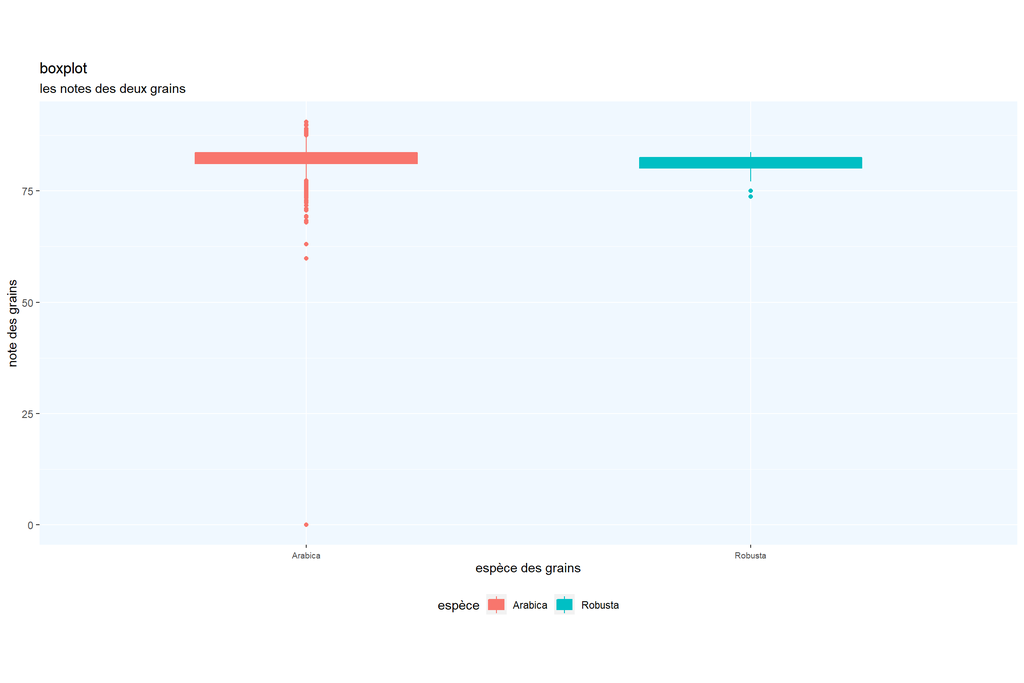

```r
 df%>%filter(espèce %in% c("Arabica","Robusta"))%>%
  select(espèce,notes)%>%
   group_by(espèce)%>%
   ggplot(aes(x=espèce,y=notes))+
   geom_boxplot(aes(color = espèce, fill = espèce),position = "dodge",width=0.5)+
   coord_fixed(ratio = 1/100)+
   scale_size_area(max_size = 30)+
   theme(axis.text.x = element_text(size = 7, vjust = 0.5, hjust = 0.5),legend.position="bottom")+
  theme(panel.background = element_rect(fill = "aliceblue"))+
   labs(x="espèce des grains",y="note des grains",subtitle="les notes des deux grains",title = "boxplot")->p2
 p2
```

- D’après les deux graphiques, on peut bien savoir que la note moyenne de l’Arabica est un peu plus haute que le Robusta, mais les notes de Robusta est plus centralisées, c’est à dire que la qualié de Robusta est plus stable.

> Question 3 : Est ce que il existe une relation entre la calsse de douceur et la note de grain de café ?

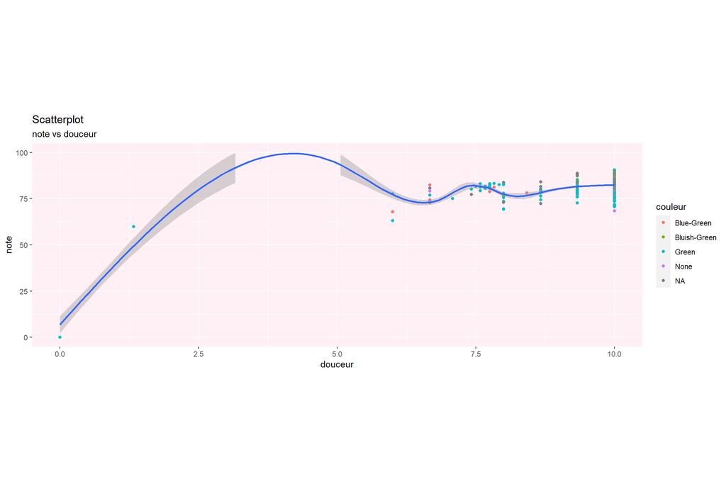

```r
gg1 <- df%>%
  ggplot(aes(x = douceur, y = notes))+
  geom_point(aes(col=couleur)) +
  geom_smooth() +
  xlim(c(0, 10)) +
  ylim(c(0, 100)) +
  scale_size_area(max_size = 30)+
  coord_fixed(ratio = 1/30)+
  theme(panel.background = element_rect(fill = "lavenderblush"))+
  labs(subtitle="note vs douceur",
       y="note",
       x="douceur",
       title="Scatterplot")

plot(gg1)
```

- la classe de douceur des grains de café sont souvent entre 6 et 10, mais la classe de douceur et la note ont pas une relation très fort, parce que il y a pleins de grains qui ont la classe de douceur de 10, mais la différence de ses notes est très grande, la note est souvent entre 65 et 90, d’après graphique il ne peut pas montre que la classe de douceur peut influencer fortement la qualité de grain de café. Donc on va pas continuer de étudier leur relation.

> Question 4: Est ce que il existe une relation entre la calsse d’acidité et la note de grain de café ?

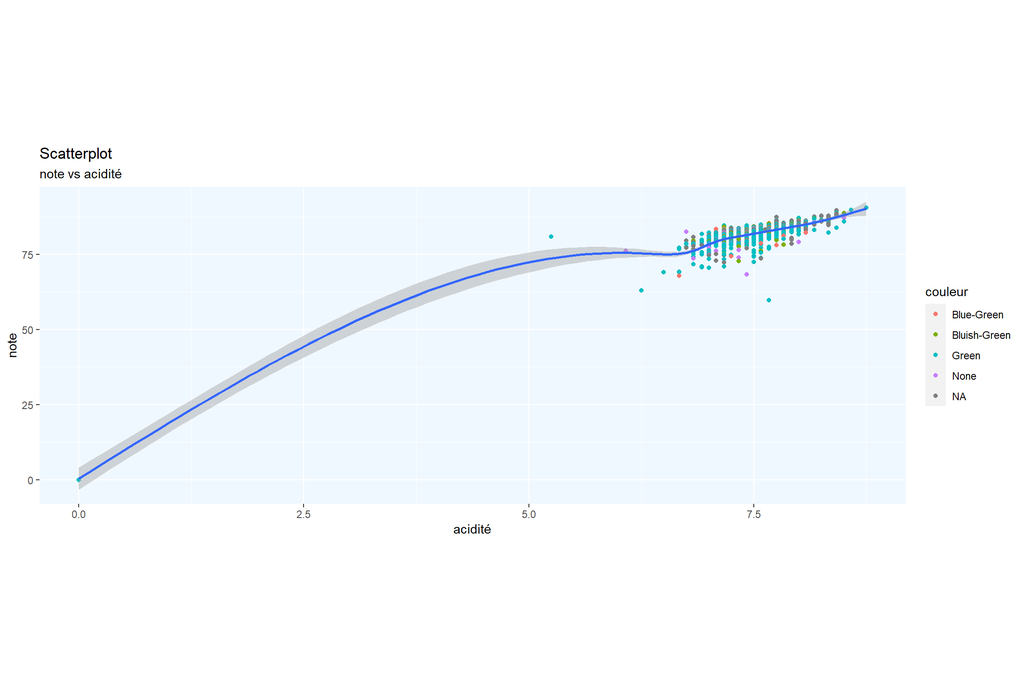

```r
gg2<-df%>%
  ggplot(aes(x = acidité, y = notes))+
  geom_point(aes(col=couleur))+
  geom_smooth()+
coord_equal(ratio = 1,
                    xlim = c(0, 10),
                    ylim = c(0, 100))+
  scale_size_area(max_size = 30)+
  coord_fixed(ratio = 1/30)+
  theme(panel.background = element_rect(fill = "aliceblue"))+
   labs(subtitle="note vs acidité",
       y="note",
       x="acidité",
       title="Scatterplot")
plot(gg2)
```

- D’après cette graphique, on peut voir clairement, il existe une relation fort entre la classe de acidité et la qualité de grain , quand la classe d’acidité plus haute, la note de grain de café est plus haute, ils ont une relation forte, pour montrer que notre résultat, on va continuer d’étudier leur relation par la méthode Regression linaire dans Question 5.

```r
library(tidyverse)
library(broom)

resultat_regr<-cor.test(df$acidité, df$notes)
resultat_regr
```

```
##
##  Pearson's product-moment correlation
##
## data:  df$acidité and df$notes
## t = 48.255, df = 1337, p-value < 2.2e-16
## alternative hypothesis: true correlation is not equal to 0
## 95 percent confidence interval:
##  0.7766126 0.8157642
## sample estimates:
##       cor
## 0.7970242
```

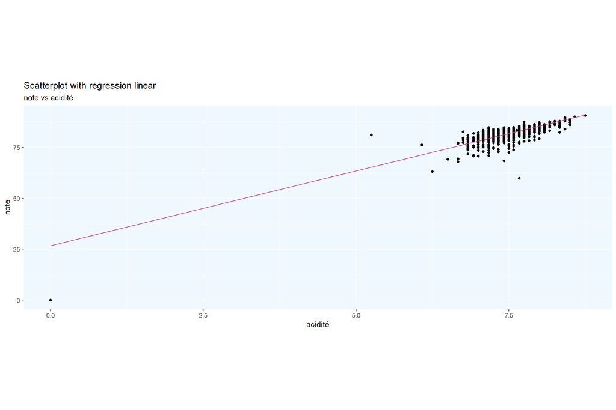

```r
lm(notes ~ acidité , data = df) %>%
  augment() %>%
  ggplot(aes(x = acidité, y = notes))+
  geom_point()+
  geom_line(aes(x = acidité, y =.fitted), color = "violetred3")+
  geom_segment(aes(x = acidité, xend = acidité, y = notes, yend = notes ))+
  coord_fixed(ratio = 1/30)+
  theme(panel.background = element_rect(fill = "aliceblue"))+
  labs(subtitle="note vs acidité",
       y="note",
       x="acidité",
       title="Scatterplot with regression linear")
```

## IV) Conclusion

Grâce au jeu de données, on a bien obtenu des connaissance de gain de café.